# Lecture 301

2021-10-03

## Data visualisation

## Recap

**Prev**: Reproducibility

- 221 Reproducibility
- 222 R and Markdown
- 223 Git
- 224 Practical session

**Now**: Data visualisation

- Grammar of graphics
- ggplot2

## Grammar of graphics

Grammars provide rules for languages

*“The grammar of graphics takes us beyond a limited set of charts (words) to an almost unlimited world of graphical forms (statements)”* (Wilkinson, 2005)

Statistical graphic specifications are expressed in six statements:

1. **Data** manipulation
2. **Variable** transformations (e.g., rank),
3. **Scale** transformations (e.g., log),
4. **Coordinate system** transformations (e.g., polar),
5. **Element**: mark (e.g., points) and visual variables (e.g., color)
6. **Guides** (axes, legends, etc.).

## Visual variables

A **visual variable** is an aspect of a **mark** that can be controlled to change its appearance.

Visual variables include:

- Size
- Shape
- Orientation
- Colour (hue)
- Colour value (brightness)
- Texture
- Position (2 dimensions)

## ggplot2

The `ggplot2` library offers a series of functions for creating graphics **declaratively**, based on the Grammar of Graphics.

To create a graph in `ggplot2`:

- provide the data
- specify elements
  - which visual variables (`aes`)
  - which marks (e.g., `geom_point`)
- apply transformations
- guides

## Aesthetics

The `aes` element provides a *“mapping”* from the data *columns* (attributes) to the graphic’s *visual variables*, including:

- `x` and `y`
- `fill` (fill colour) and `colour` (border colour)
- `shape`
- `size`

```r
data %>%
  ggplot2::ggplot(
    aes(
      x = column_1,
      y = column_2
    )
  )
```

## Graphical primitives

Marks (graphical primitives) can be specified through a series of functions, such as `geom_line`, `geom_bar` or `geom_point`

These can be added to the construction of the graph using `+`

```r
ggplot2::ggplot(
  aes(
    x = column_1, y = column_2
  )
) +
ggplot2::geom_line()
```

## ggplot2::geom_line

- `x`: a column to *“map”* to the x-axis, e.g. days (category)
- `y`: a column to *“map”* to the y-axis, e.g. delay (continuous)
- `ggplot2::geom_line`: line mark (graphical primitive)

```r
nycflights13::flights %>%
  dplyr::filter(!is.na(dep_delay) & month == 11) %>%
  dplyr::mutate(flight_date = ISOdate(year, month, day)) %>%
  dplyr::group_by(flight_date) %>%
  dplyr::summarize(tot_dep_delay = sum(dep_delay)) %>%
  ggplot2::ggplot(aes(
    x = flight_date,
    y = tot_dep_delay
  )) +
  ggplot2::geom_line()
```

## ggplot2::geom_line

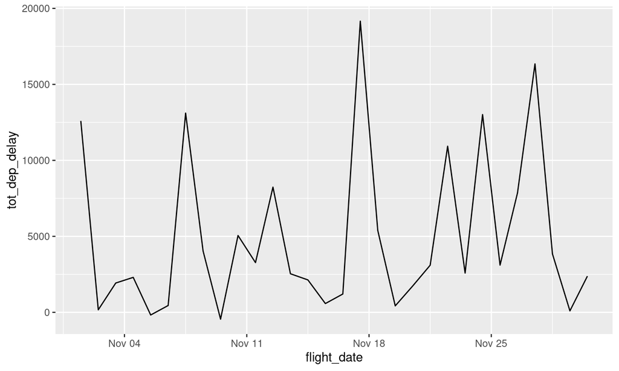

## ggplot2::geom_col

- `x`: a column to *“map”* to the x-axis, e.g. days (category)
- `y`: a column to *“map”* to the y-axis, e.g. delay (continuous)
- `ggplot2::geom_col`: bar mark (graphical primitive)
  - `ggplot2::geom_bar` instead illustrates count per category

```r
nycflights13::flights %>%
  dplyr::filter(!is.na(dep_delay) & month == 11) %>%
  dplyr::mutate(flight_date = ISOdate(year, month, day)) %>%
  dplyr::group_by(flight_date) %>%
  dplyr::summarize(tot_dep_delay = sum(dep_delay)) %>%
  ggplot2::ggplot(aes(
    x = flight_date,
    y = tot_dep_delay
  )) +
  ggplot2::geom_col()
```

## ggplot2::geom_col

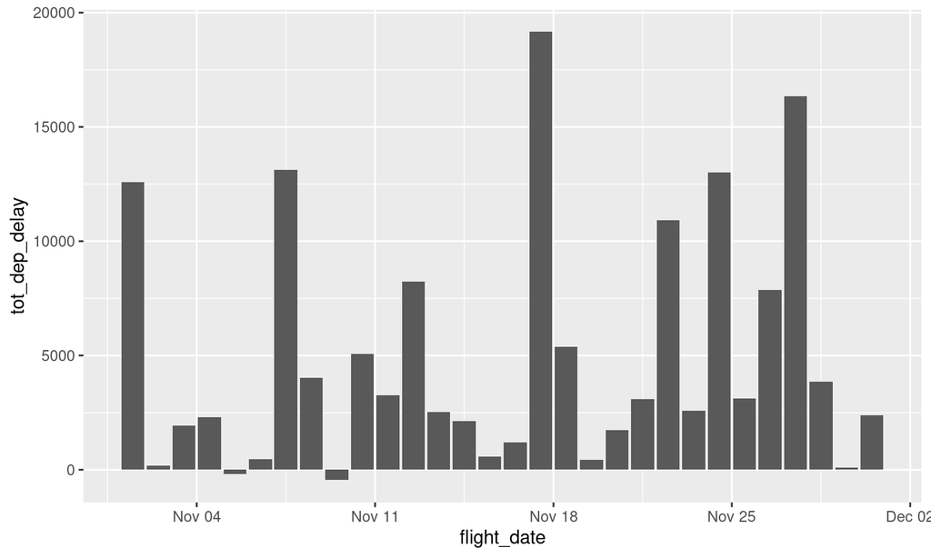

## ggplot2::geom_col

… then, why not add some colour?

- `fill`: a column to *“map”* to the visual variable *colour* as fill of the mark, e.g. origin (category)
  - `colour` can be used to *“map”* a column to the visual variable *colour* as border of the mark

```r
nycflights13::flights %>%
  dplyr::filter(!is.na(dep_delay) & month == 11) %>%
  dplyr::mutate(flight_date = ISOdate(year, month, day)) %>%
  dplyr::group_by(flight_date, origin) %>%
  dplyr::summarize(tot_dep_delay = sum(dep_delay)) %>%
  ggplot2::ggplot(aes(
    x = flight_date,
    y = tot_dep_delay,
    fill = origin
  )) +
  ggplot2::geom_col()
```

## ggplot2::geom_col

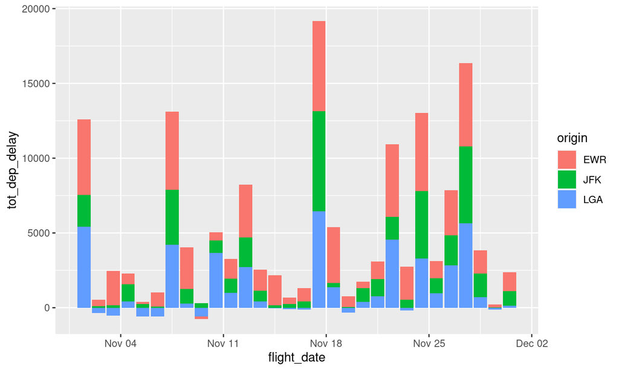

## Histograms

- `x` a column to *“map”* to the x-axis, e.g. delay (continuous)
- `ggplot2::geom_histogram` to illustrate count over intervals of continuous variable on x-axis
  - `ggplot2::geom_bar` instead illustrates count per category

```r
nycflights13::flights %>%
  dplyr::filter(month == 11) %>%
  ggplot2::ggplot(
    aes(
      x = dep_delay
    )
  ) +
  ggplot2::geom_histogram(
    binwidth = 10
  )
```

## Histograms

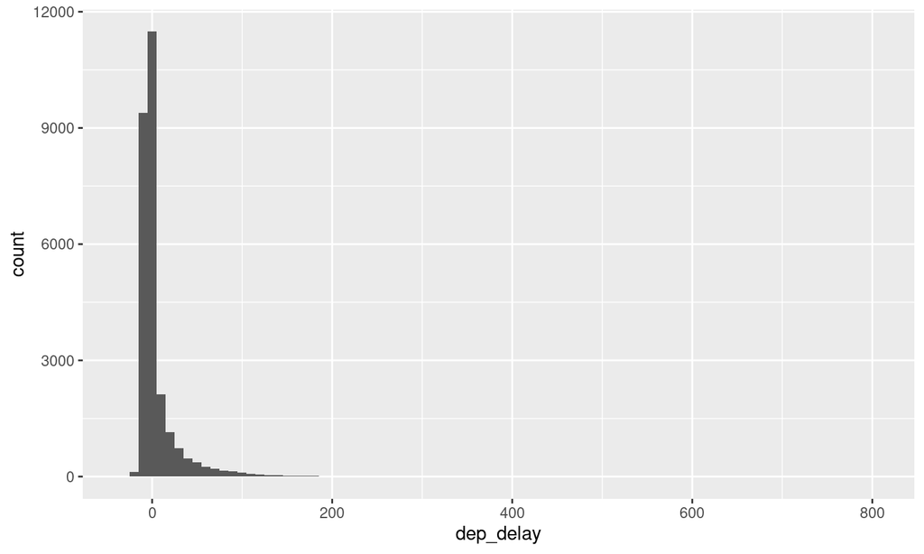

## Scatterplots

- `x` and `y` variables to plot
- `ggplot2::geom_point`

```r
nycflights13::flights %>%
  dplyr::filter(
    month == 11,
    carrier == "US",
    !is.na(dep_delay),
    !is.na(arr_delay)
  ) %>%
  ggplot2::ggplot(aes(
    x = dep_delay,
    y = arr_delay
  )) +
  ggplot2::geom_point()
```

## Scatterplots

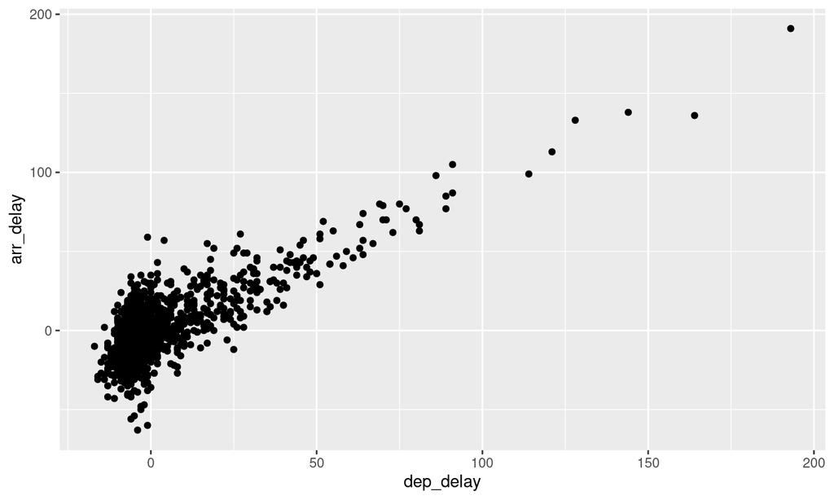

## Overlapping points

- `x` and `y` variables to plot
- `ggplot2::geom_count` counts overlapping points and maps the count to size

```r
nycflights13::flights %>%
  dplyr::filter(
    month == 11, carrier == "US",
    !is.na(dep_delay), !is.na(arr_delay)
  ) %>%
  ggplot2::ggplot(aes(
    x = dep_delay,
    y = arr_delay
  )) +
  ggplot2::geom_count()
```

## Overlapping points

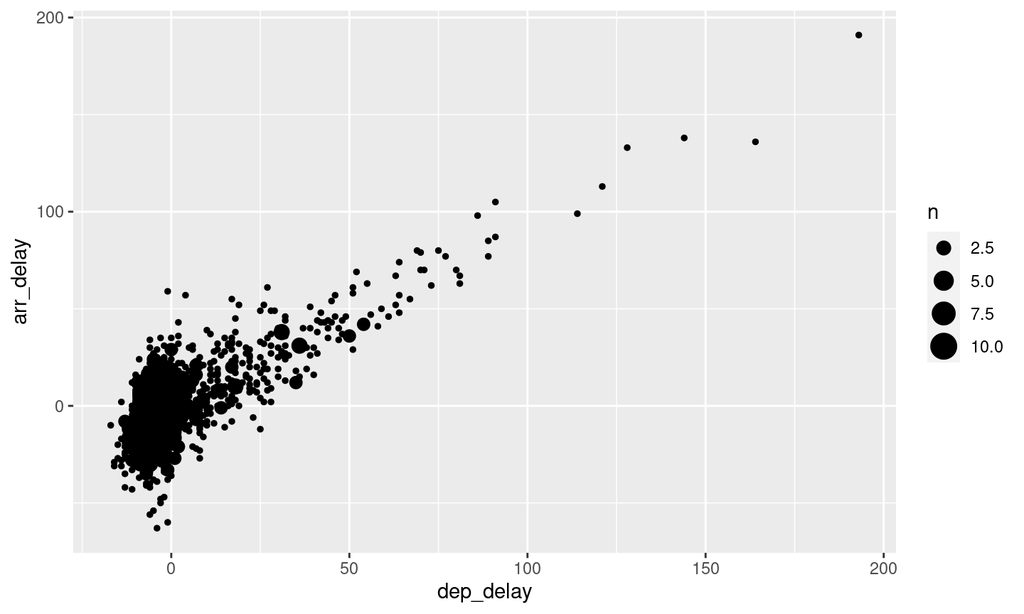

## Bin counts

- `x` and `y` variables to plot
- `ggplot2::geom_bin2d` with 10 minutes binwidth

```r
nycflights13::flights %>%
  dplyr::filter(
    month == 11,
    carrier == "US",
    !is.na(dep_delay),
    !is.na(arr_delay)
  ) %>%
  ggplot2::ggplot(aes(
    x = dep_delay,
    y = arr_delay
  )) +
  ggplot2::geom_bin2d(binwidth = 10)
```

## Bin counts

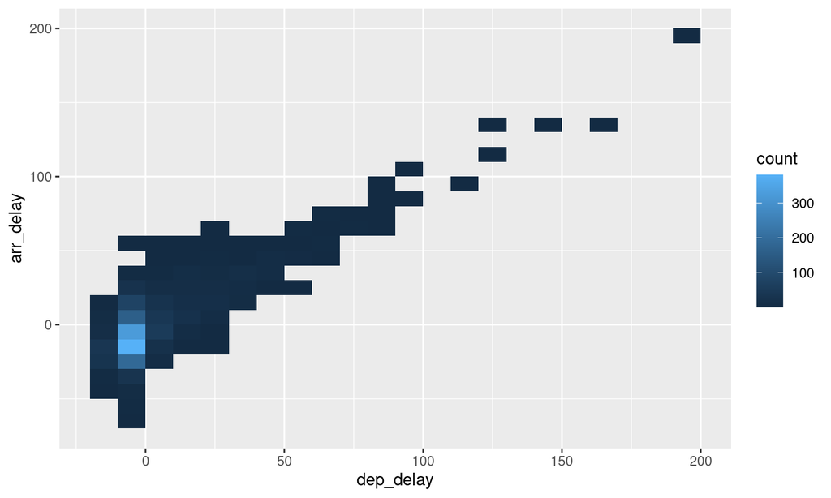

## Coordinates transformations

- `ggplot2::coord_fixed` manipulates coordinates property
- `ggplot2::theme_bw` classic dark-on-light theme

```r
nycflights13::flights %>%
  dplyr::filter(
    month == 11,
    carrier == "US",
    !is.na(dep_delay),
    !is.na(arr_delay)
  ) %>%
  ggplot2::ggplot(aes(
    x = dep_delay,
    y = arr_delay
  )) +
  ggplot2::geom_bin2d(binwidth = 10) +
  ggplot2::coord_fixed(ratio = 1) +
  theme_bw()
```

## Coordinates transformations

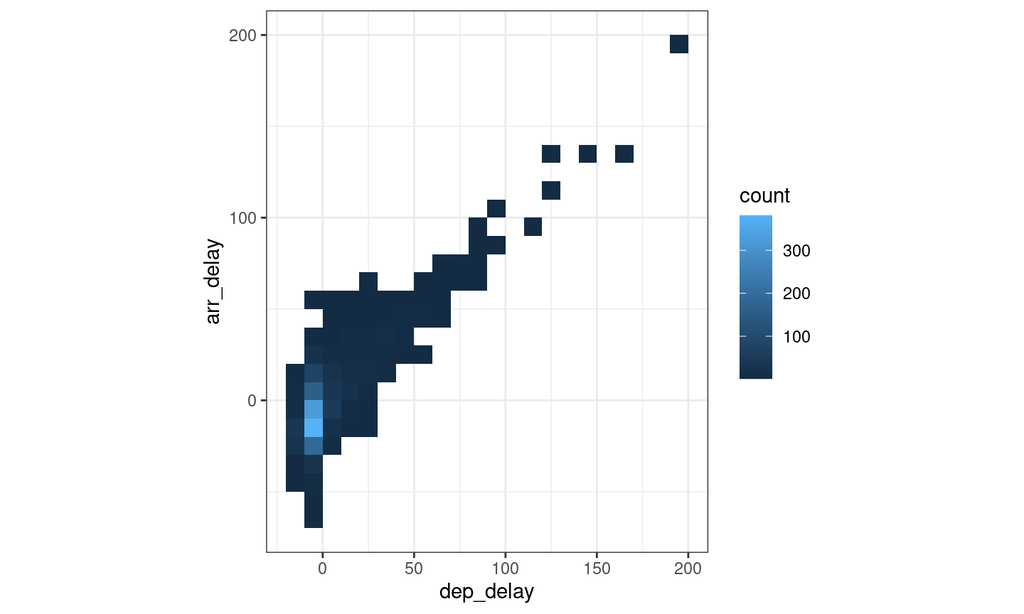

## Summary

Data visualisation

- Grammar of graphics
- ggplot2

**Next**: Descriptive statistics

- pastecs::stat.desc
- dplyr::across